# Capstone Project - Car accident severity

### Applied Data Science Capstone by IBM/Coursera

#### By: Archer Darrach

### Import Libraries

```python
import pandas as pd
import numpy as np
import re
import itertools

# Matplotlib and associated plotting modules
import matplotlib.pyplot as plt
import matplotlib as mpl
import matplotlib.cm as cm
import matplotlib.colors as mcolors
import seaborn as sns

# Modeling Libraries
from sklearn.preprocessing import StandardScaler
from sklearn.model_selection import train_test_split, GridSearchCV
from sklearn.linear_model import LogisticRegression
from sklearn.metrics import jaccard_score, log_loss, confusion_matrix, classification_report, accuracy_score
from sklearn.tree import DecisionTreeClassifier, plot_tree
```

## Report: Table of Contents

- Introduction
- Data
- Methodology
- Analysis
- Results & Discussion
- Conclusion

## Introduction

Often it is hard for first responders to take care of all the calls they recieve causing some incidents to have a longer response time. This project approaches this problem with a machine learning model that classifies the accident as more severe or less severe. Not only does this project aim to help first responders prioritize calls but this report also proactivly shows drivers the conditions, locations, and other patterns that increase the likelyhood of a severe accident.

## Data

#### Import Data

```python
US_Accidents_June20 = pd.read_csv("US_Accidents_June20.csv")
```

Create new `raw_df` that is a replicate of the imported one so that we dont have to import it every time we need to change something.

```python
raw_df = US_Accidents_June20.copy(deep = True)
```

For this project I used the [US Accidents](https://www.kaggle.com/sobhanmoosavi/us-accidents) dataset from kaggle. This dataset has car accident data from 2016 to 2020 in 49 states. This data has three main categories: infrastructure, location, and weather.

```python
raw_df.head()
```

|  | ID | Source | TMC | Severity | Start_Time | End_Time | Start_Lat | Start_Lng | End_Lat | End_Lng | ... | Roundabout | Station | Stop | Traffic_Calming | Traffic_Signal | Turning_Loop | Sunrise_Sunset | Civil_Twilight | Nautical_Twilight | Astronomical_Twilight |
| --- | --- | --- | --- | --- | --- | --- | --- | --- | --- | --- | --- | --- | --- | --- | --- | --- | --- | --- | --- | --- | --- |
| 0 | A-1 | MapQuest | 201.0 | 3 | 2016-02-08 05:46:00 | 2016-02-08 11:00:00 | 39.865147 | -84.058723 | NaN | NaN | ... | False | False | False | False | False | False | Night | Night | Night | Night |
| 1 | A-2 | MapQuest | 201.0 | 2 | 2016-02-08 06:07:59 | 2016-02-08 06:37:59 | 39.928059 | -82.831184 | NaN | NaN | ... | False | False | False | False | False | False | Night | Night | Night | Day |
| 2 | A-3 | MapQuest | 201.0 | 2 | 2016-02-08 06:49:27 | 2016-02-08 07:19:27 | 39.063148 | -84.032608 | NaN | NaN | ... | False | False | False | False | True | False | Night | Night | Day | Day |
| 3 | A-4 | MapQuest | 201.0 | 3 | 2016-02-08 07:23:34 | 2016-02-08 07:53:34 | 39.747753 | -84.205582 | NaN | NaN | ... | False | False | False | False | False | False | Night | Day | Day | Day |
| 4 | A-5 | MapQuest | 201.0 | 2 | 2016-02-08 07:39:07 | 2016-02-08 08:09:07 | 39.627781 | -84.188354 | NaN | NaN | ... | False | False | False | False | True | False | Day | Day | Day | Day |

5 rows × 49 columns

This Data has 3,513,617 data points with 49 features that are made up of:

- 21 object type features
- 14 float type features
- 1 int type feature
- 13 bool features

```python
objectl = []
floatl = []
intl = []
booll = []
for col in raw_df.columns:
    if raw_df[col].dtypes == 'object':
        objectl.append(col)
    elif raw_df[col].dtypes == 'float64':
        floatl.append(col)
    elif raw_df[col].dtypes == 'int64':
        intl.append(col)
    elif raw_df[col].dtypes == 'bool':
        booll.append(col)
    else:
        print(col, ":", raw_df[col].dtypes)
print("Data Types:")
print()
print("Object: \n",objectl)
print()
print("Float: \n" ,floatl)
print()
print("Int: \n" ,intl)
print()
print("Bool: \n", booll)
print()
print("Shape:", raw_df.shape)
```

```
Data Types:

Object:
 ['ID', 'Source', 'Start_Time', 'End_Time', 'Description', 'Street', 'Side', 'City', 'County', 'State', 'Zipcode', 'Country', 'Timezone', 'Airport_Code', 'Weather_Timestamp', 'Wind_Direction', 'Weather_Condition', 'Sunrise_Sunset', 'Civil_Twilight', 'Nautical_Twilight', 'Astronomical_Twilight']

Float:
 ['TMC', 'Start_Lat', 'Start_Lng', 'End_Lat', 'End_Lng', 'Distance(mi)', 'Number', 'Temperature(F)', 'Wind_Chill(F)', 'Humidity(%)', 'Pressure(in)', 'Visibility(mi)', 'Wind_Speed(mph)', 'Precipitation(in)']

Int:
 ['Severity']

Bool:
 ['Amenity', 'Bump', 'Crossing', 'Give_Way', 'Junction', 'No_Exit', 'Railway', 'Roundabout', 'Station', 'Stop', 'Traffic_Calming', 'Traffic_Signal', 'Turning_Loop']

Shape: (3513617, 49)
```

First, I wanted to see if I had NaN values. I created a dataframe that took the percent of missing values from each feature so that I could see what columns needed to be removed or fixed.

```python
# find % of missing data in each column
missing = pd.DataFrame(raw_df.isnull().sum()).reset_index()
missing.columns = ['Feature', 'Missing_Percent(%)']
missing['Missing_Percent(%)'] = missing['Missing_Percent(%)'].apply(lambda x: x / raw_df.shape[0] * 100)
missing.loc[missing['Missing_Percent(%)']>0,:].sort_values('Missing_Percent(%)', ascending = False).style.background_gradient(cmap='Blues')
```

|  | Feature | Missing_Percent(%) |
| --- | --- | --- |
| 8 | End_Lat | 70.548896 |
| 9 | End_Lng | 70.548896 |
| 12 | Number | 64.402694 |
| 30 | Precipitation(in) | 57.657793 |
| 24 | Wind_Chill(F) | 53.171675 |
| 2 | TMC | 29.451104 |
| 29 | Wind_Speed(mph) | 12.938490 |
| 31 | Weather_Condition | 2.166941 |
| 27 | Visibility(mi) | 2.158915 |
| 25 | Humidity(%) | 1.983341 |
| 23 | Temperature(F) | 1.870779 |
| 28 | Wind_Direction | 1.675595 |
| 26 | Pressure(in) | 1.590441 |
| 22 | Weather_Timestamp | 1.233003 |
| 21 | Airport_Code | 0.192337 |
| 20 | Timezone | 0.110428 |
| 18 | Zipcode | 0.030424 |
| 45 | Sunrise_Sunset | 0.003273 |
| 46 | Civil_Twilight | 0.003273 |
| 47 | Nautical_Twilight | 0.003273 |
| 48 | Astronomical_Twilight | 0.003273 |
| 15 | City | 0.003188 |
| 11 | Description | 0.000028 |

## Methodology

For this project the first thing I had to do was clean the columns and put them into categorigal features since there are few continuous features. Here I focused on creating time features such as **year**, **month**, **day**, etc. as well as simplifying the `Wind_Direction` and `Weather_Condition` condition.

The second step in my analysis was creating a new data frame where I balanced the severity. This was necesary because severity is on a scale of 1-4 (less to more severe) and Severity levels 1 and 2 have about a million more data points than Severity levels 3 and 4. This is likely because minor accidents happen more fequently, but they have to be even for best resuts in modeling.

Third I graphed all the features that seemed important the data. These fetures are the ones that fall under the three main categories of the data set. Along with this I looked at the correlation between the features I graphed and severity.

Finaly, I built a Logistic Regression and Decision Tree model that predict if the severity will be 1/2 or 3/4.

## Analysis

First Thing is to clean the data.

I began to look through different categorical features to make sure there were no data points that were input wrong.

```python
raw_df["Side"].value_counts()
```

```
R    2879797
L     633819
           1
Name: Side, dtype: int64
```

Remove the one column that has no value for Side

```python
no_side = raw_df[(raw_df["Side"]!= "R") & (raw_df["Side"] != "L")].index

raw_df.drop(no_side, inplace = True)
```

I need to make the names for wind direction uniform. For example, there was "Calm" and "CALM", "North" and "N" etc. but I need to change it to 6 categories:

- CALM
- VAR (variable wind direction)
- N
- S
- E
- W

```python
raw_df["Wind_Direction"].value_counts()
```

```
Calm        368282
CALM        217424
SSW         181645
South       177225
WNW         174114
SW          172252
WSW         165738
NW          164928
West        164624
SSE         163649
North       153252
NNW         147047
SE          132051
NNE         117475
NE          115931
ESE         114855
Variable    113897
ENE         112626
S           103970
East        103462
W            95115
N            70516
VAR          64523
E            60141
Name: Wind_Direction, dtype: int64
```

```python
# Clean wind direction
raw_df.loc[raw_df['Wind_Direction']=='Calm','Wind_Direction'] = 'CALM'
raw_df.loc[(raw_df['Wind_Direction']=='West')|(raw_df['Wind_Direction']=='WSW')|(raw_df['Wind_Direction']=='WNW'),'Wind_Direction'] = 'W'
raw_df.loc[(raw_df['Wind_Direction']=='South')|(raw_df['Wind_Direction']=='SSW')|(raw_df['Wind_Direction']=='SSE')|(raw_df['Wind_Direction']=='SE')|(raw_df['Wind_Direction']=='SW'),'Wind_Direction'] = 'S'
raw_df.loc[(raw_df['Wind_Direction']=='North')|(raw_df['Wind_Direction']=='NNW')|(raw_df['Wind_Direction']=='NNE')|(raw_df['Wind_Direction']=='NE')|(raw_df['Wind_Direction']=='NW'),'Wind_Direction'] = 'N'
raw_df.loc[(raw_df['Wind_Direction']=='East')|(raw_df['Wind_Direction']=='ESE')|(raw_df['Wind_Direction']=='ENE'),'Wind_Direction'] = 'E'
raw_df.loc[raw_df['Wind_Direction']=='Variable','Wind_Direction'] = 'VAR'
print("Wind Direction after simplification: ", raw_df['Wind_Direction'].unique())
```

```
Wind Direction after simplification:  ['CALM' 'S' 'W' 'N' 'VAR' 'E' nan]
```

Next I wanted to create features from the `Start_Time` column. First I had to change it to a datetime format column so that pandas could easily manipulate it.

```python
# fix datetime type
raw_df['Start_Time'] = pd.to_datetime(raw_df['Start_Time'])
```

```python
raw_df['Year'] = raw_df['Start_Time'].dt.year

nmonth = raw_df['Start_Time'].dt.month
raw_df['Month'] = nmonth

raw_df['Weekday'] = raw_df['Start_Time'].dt.weekday

days_each_month = np.cumsum(np.array([0,31,28,31,30,31,30,31,31,30,31,30,31]))
nday = [days_each_month[arg-1] for arg in nmonth.values]
nday = nday + raw_df["Start_Time"].dt.day.values
raw_df['Day'] = nday

raw_df['Hour'] = raw_df['Start_Time'].dt.hour

raw_df['Minute'] = raw_df['Hour'] * 60.0 + raw_df["Start_Time"].dt.minute

print(raw_df.loc[:4,['Start_Time', 'Year', 'Month', 'Weekday', 'Day', 'Hour', 'Minute']])

raw_df = raw_df.drop(['Start_Time', 'End_Time', 'Weather_Timestamp'], axis = 1)
```

```
           Start_Time  Year  Month  Weekday  Day  Hour  Minute
0 2016-02-08 05:46:00  2016      2        0   39     5   346.0
1 2016-02-08 06:07:59  2016      2        0   39     6   367.0
2 2016-02-08 06:49:27  2016      2        0   39     6   409.0
3 2016-02-08 07:23:34  2016      2        0   39     7   443.0
4 2016-02-08 07:39:07  2016      2        0   39     7   459.0
```

Now, similar to wind direction, I need to simplify the `Weather_Condition` columns and create new columns for types of weather that are either 1 or 0 depending on if the weather condition matches the column name.

```python
raw_df["Weather_Condition"].value_counts()
```

```
Clear                       808201
Fair                        547721
Mostly Cloudy               488094
Overcast                    382485
Partly Cloudy               344815
                             ...
Thunder and Hail / Windy         1
Freezing Drizzle                 1
Heavy Smoke                      1
Snow and Thunder                 1
Thunder and Hail                 1
Name: Weather_Condition, Length: 127, dtype: int64
```

```python
# show distinctive weather conditions
weather ='!'.join(raw_df['Weather_Condition'].dropna().unique().tolist())
weather = np.unique(np.array(re.split(
    "!|\s/\s|\sand\s|\swith\s|Partly\s|Mostly\s|Blowing\s|Freezing\s", weather))).tolist()
print("Weather Conditions: ", weather)
```

```
Weather Conditions:  ['', 'Clear', 'Cloudy', 'Drifting Snow', 'Drizzle', 'Dust', 'Dust Whirls', 'Dust Whirls Nearby', 'Dust Whirlwinds', 'Fair', 'Fog', 'Funnel Cloud', 'Hail', 'Haze', 'Heavy ', 'Heavy Drizzle', 'Heavy Ice Pellets', 'Heavy Rain', 'Heavy Rain Shower', 'Heavy Rain Showers', 'Heavy Slee…
```

```python
# Create a 1 0 (True False) column for different weather conditions

raw_df['Clear'] = np.where(raw_df['Weather_Condition'].str.contains('Clear', case=False, na = False), 1, 0)
raw_df['Cloud'] = np.where(raw_df['Weather_Condition'].str.contains('Cloud|Overcast', case=False, na = False), 1, 0)
raw_df['Rain'] = np.where(raw_df['Weather_Condition'].str.contains('Rain|storm', case=False, na = False), 1, 0)
raw_df['Heavy_Rain'] = np.where(raw_df['Weather_Condition'].str.contains('Heavy Rain|Rain Shower|Heavy T-Storm|Heavy Thunderstorms', case=False, na = False), 1, 0)
raw_df['Snow'] = np.where(raw_df['Weather_Condition'].str.contains('Snow|Sleet|Ice', case=False, na = False), 1, 0)
raw_df['Heavy_Snow'] = np.where(raw_df['Weather_Condition'].str.contains('Heavy Snow|Heavy Sleet|Heavy Ice Pellets|Snow Showers|Squalls', case=False, na = False), 1, 0)
raw_df['Fog'] = np.where(raw_df['Weather_Condition'].str.contains('Fog', case=False, na = False), 1, 0)

# Assign NA to created weather features where 'Weather_Condition' is null.
weather = ['Clear','Cloud','Rain','Heavy_Rain','Snow','Heavy_Snow','Fog']

for i in weather:
  raw_df.loc[raw_df['Weather_Condition'].isnull(),i] = raw_df.loc[raw_df['Weather_Condition'].isnull(),'Weather_Condition']

raw_df.loc[:,['Weather_Condition'] + weather]

raw_df = raw_df.drop(['Weather_Condition'], axis=1)
```

```python
for col in weather:
    print(col, ":\n")
    print(raw_df[col].value_counts(), "\n----------------------------------\n")
```

```
Clear :

0    2629277
1     808201
Name: Clear, dtype: int64
----------------------------------

Cloud :

0    1792908
1    1644570
Name: Cloud, dtype: int64
----------------------------------

Rain :

0    3174037
1     263441
Name: Rain, dtype: int64
----------------------------------

Heavy_Rain :

0    3416501
1      20977
Name: Heavy_Rain, dtype: int64
----------------------------------

Snow :

0    3377587
1      59891
Name: Snow, dtype: int64
----------------------------------

Heavy_Snow :

0    3435831
1       1647
Name: Heavy_Snow, dtype: int64
----------------------------------

Fog :

0    3401306
1      36172
Name: Fog, dtype: int64
----------------------------------
```

Drop na values from the following list of features

```python
raw_df = raw_df.dropna(subset=['City','Zipcode', 'Airport_Code', 'Sunrise_Sunset', 'Civil_Twilight', 'Nautical_Twilight', 'Astronomical_Twilight'])
```

Now I am creating a new column that is going to be the target variable in my models. This categorizes the severity as 1 or 0 with 1 being more severe

| Value | Description |
| --- | --- |
| 1 | If severity = 3 or 4 |
| 0 | If severity = 1 or 2 |

```python
raw_df['severity34'] = 0
raw_df['severity34'] = np.where(raw_df['Severity'].astype(str).str.contains("3|4", na = False), 1, 0)
raw_df['severity34'] = raw_df['severity34'].astype(int)
raw_df.severity34.value_counts()
```

```
0    2398124
1    1108619
Name: severity34, dtype: int64
```

Now I need to simplify the street column. To do this I am going to split all the street names at every space and find the unique words. Since there are so many I am going to filter it to keep only the top 40 results, and from there remove random results such as ' '.

```python
from collections import Counter
# create a list of top 40 most common words in street name
st_type =' '.join(raw_df['Street'].unique().tolist()) # flat the array of street name
st_type = re.split(" |-", st_type) # split the long string by space and hyphen
st_type = [x[0] for x in Counter(st_type).most_common(40)] # select the 40 most common words
print('the 40 most common words')
print(*st_type, sep = ", ")
```

```
the 40 most common words
Rd, , Dr, St, Ave, N, S, E, W, Ln, Blvd, Highway, Way, Ct, State, Hwy, NE, Pkwy, SW, Pl, SE, NW, Road, Old, Cir, Route, US, Creek, Hill, Park, County, Lake, Trl, Valley, Ridge, Mill, River, Pike, Oak, Ter
```

```python
# Remove some irrelevant words and add spaces and hyphen back
st_type= [' Rd', ' St', ' Dr', ' Ave', ' Blvd', ' Ln', ' Highway', ' Pkwy', ' Hwy',
          ' Way', ' Ct', 'Pl', ' Road', 'US-', 'Creek', ' Cir', 'Hill', 'Route',
          'I-', 'Trl', 'Valley', 'Ridge', 'Pike', ' Fwy', 'River']
print(*st_type, sep = ", ")
```

```
 Rd,  St,  Dr,  Ave,  Blvd,  Ln,  Highway,  Pkwy,  Hwy,  Way,  Ct, Pl,  Road, US-, Creek,  Cir, Hill, Route, I-, Trl, Valley, Ridge, Pike,  Fwy, River
```

```python
# for each word create a boolean column
for i in st_type:
  raw_df[i.strip()] = np.where(raw_df['Street'].str.contains(i, case=True, na = False), 1, 0)
raw_df.loc[raw_df['Road']==1,'Rd'] = 1
raw_df.loc[raw_df['Highway']==1,'Hwy'] = 1
```

##### Make Column Headers Lower Case

```python
raw_df.columns= raw_df.columns.str.strip().str.lower()
```

##### Rename Column names

```python
rename = {'sunrise_sunset': 'day_night',
          'start_lat': 'lat',
          'start_lng': 'long'
         }

raw_df = raw_df.rename(columns = rename)
```

##### Drop Columns

```python
drop = ['id','source', 'tmc',  'end_lat', 'end_lng', 'description', 'number', 'country',  'wind_chill(f)', 'turning_loop', 'civil_twilight', 'nautical_twilight', 'astronomical_twilight']

raw_df = raw_df.drop(columns = drop)
```

```python
raw_df.head(10)
```

|  | severity | lat | long | distance(mi) | street | side | city | county | state | zipcode | ... | cir | hill | route | i- | trl | valley | ridge | pike | fwy | river |
| --- | --- | --- | --- | --- | --- | --- | --- | --- | --- | --- | --- | --- | --- | --- | --- | --- | --- | --- | --- | --- | --- |
| 0 | 3 | 39.865147 | -84.058723 | 0.01 | I-70 E | R | Dayton | Montgomery | OH | 45424 | ... | 0 | 0 | 0 | 1 | 0 | 0 | 0 | 0 | 0 | 0 |
| 1 | 2 | 39.928059 | -82.831184 | 0.01 | Brice Rd | L | Reynoldsburg | Franklin | OH | 43068-3402 | ... | 0 | 0 | 0 | 0 | 0 | 0 | 0 | 0 | 0 | 0 |
| 2 | 2 | 39.063148 | -84.032608 | 0.01 | State Route 32 | R | Williamsburg | Clermont | OH | 45176 | ... | 0 | 0 | 1 | 0 | 0 | 0 | 0 | 0 | 0 | 0 |
| 3 | 3 | 39.747753 | -84.205582 | 0.01 | I-75 S | R | Dayton | Montgomery | OH | 45417 | ... | 0 | 0 | 0 | 1 | 0 | 0 | 0 | 0 | 0 | 0 |
| 4 | 2 | 39.627781 | -84.188354 | 0.01 | Miamisburg Centerville Rd | R | Dayton | Montgomery | OH | 45459 | ... | 0 | 0 | 0 | 0 | 0 | 0 | 0 | 0 | 0 | 0 |
| 5 | 3 | 40.100590 | -82.925194 | 0.01 | Westerville Rd | R | Westerville | Franklin | OH | 43081 | ... | 0 | 0 | 0 | 0 | 0 | 0 | 0 | 0 | 0 | 0 |
| 6 | 2 | 39.758274 | -84.230507 | 0.00 | N Woodward Ave | R | Dayton | Montgomery | OH | 45417-2476 | ... | 0 | 0 | 0 | 0 | 0 | 0 | 0 | 0 | 0 | 0 |
| 7 | 3 | 39.770382 | -84.194901 | 0.01 | N Main St | R | Dayton | Montgomery | OH | 45405 | ... | 0 | 0 | 0 | 0 | 0 | 0 | 0 | 0 | 0 | 0 |
| 8 | 2 | 39.778061 | -84.172005 | 0.00 | Notre Dame Ave | L | Dayton | Montgomery | OH | 45404-1923 | ... | 0 | 0 | 0 | 0 | 0 | 0 | 0 | 0 | 0 | 0 |
| 9 | 3 | 40.100590 | -82.925194 | 0.01 | Westerville Rd | R | Westerville | Franklin | OH | 43081 | ... | 0 | 0 | 0 | 0 | 0 | 0 | 0 | 0 | 0 | 0 |

10 rows × 71 columns

## Exploration of Data

Now I want to explore my data and make graphs and plots showing the severity vs other features

```python
# copy of the data frame
df = raw_df.copy()
```

```python
df.head(1)
```

|  | severity | lat | long | distance(mi) | street | side | city | county | state | zipcode | ... | cir | hill | route | i- | trl | valley | ridge | pike | fwy | river |
| --- | --- | --- | --- | --- | --- | --- | --- | --- | --- | --- | --- | --- | --- | --- | --- | --- | --- | --- | --- | --- | --- |
| 0 | 3 | 39.865147 | -84.058723 | 0.01 | I-70 E | R | Dayton | Montgomery | OH | 45424 | ... | 0 | 0 | 0 | 1 | 0 | 0 | 0 | 0 | 0 | 0 |

1 rows × 71 columns

### Balance the data

Since there is such a large difference in the amount of accidents with 3, 4 severity and 1, 2 severity, we need to balance the data set so we can continue to exploratory analysis.

```python
# resample again
df_bl = pd.concat([df[df['severity34']==1].sample(200000, replace = True),
                   df[df['severity34']==0].sample(200000)], axis=0)
print('resampled data:\n',df_bl.severity34.value_counts())
```

```
resampled data:
 1    200000
0    200000
Name: severity34, dtype: int64
```

### Time

First I want to look through the Time features that include `year`, `month`, `weekday`, `day_night`, and `hour`

SInce the goal of my analysis it to predict severity, I want to keep 2016 and 2020 data. If I were doing a report where the year was a major factor I would remove these data points.

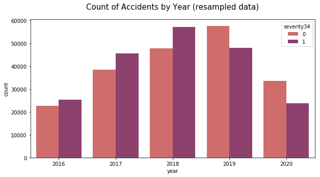

```python
plt.figure(figsize=(10,5))
df_bl.year = df_bl.year.astype(str)
labels = ["2016", "2017", "2018", "2019", "2020"]
sns.countplot(x='year', hue='severity34', data=df_bl ,palette="flare", order = labels)
plt.title('Count of Accidents by Year (resampled data)', size=15, y=1.05)
plt.show()
```

There is a a signifigant dip in car crashes in the month of july which i cannot explain.

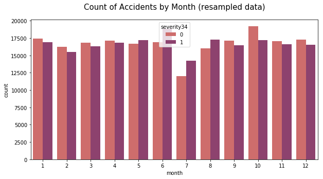

```python
plt.figure(figsize=(10,5))
df_bl.month = df_bl.month.astype(str)
labels = ["1", "2", "3", "4", "5", "6", "7", "8", "9", "10", "11", "12"]
sns.countplot(x='month', hue='severity34', data=df_bl ,palette="flare", order = labels)
plt.title('Count of Accidents by Month (resampled data)', size=15, y=1.05)
plt.show()
```

I was not expecting the weekday data to have such drastic variation, but it makes sense. During the week more people are on the roads beasue of work and school. However there is a increase of severe accidents on Friday as well as a drastic increase of severe car crash frequency on the weekends. These findings could be due to increased alcohol consumption on Friday, Saturday and Sunday.

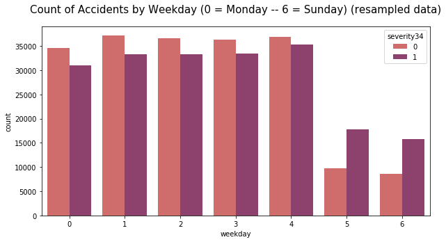

```python
plt.figure(figsize=(10,5))
df_bl.weekday = df_bl.weekday.astype(str)
labels = ["0", "1", "2", "3", "4", "5", "6"]
sns.countplot(x='weekday', hue='severity34', data=df_bl ,palette="flare", order = labels)
plt.title('Count of Accidents by Weekday (0 = Monday -- 6 = Sunday) (resampled data)', size=15, y=1.05)
plt.show()
```

This is another graph that shows what I thought it would. Durring the day there are many more drivers on the streets so there is going to be more car accidents. However, at night there is an increase in severe accident frequency likely due to factors such as worse vision due to the dark.

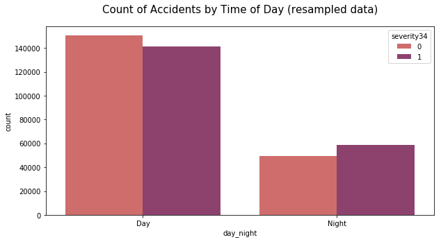

```python
plt.figure(figsize=(10,5))
df_bl.day_night = df_bl.day_night.astype(str)
labels = ["Day", "Night"]
sns.countplot(x='day_night', hue='severity34', data=df_bl ,palette="flare", order = labels)
plt.title('Count of Accidents by Time of Day (resampled data)', size=15, y=1.05)
plt.show()
```

This graphs crash severity by hour. It is clear that less people drive at night, but it is interesting that between 6 am and 12 noon there are on average more less severe crashes, but between 1 pm and 5 am there are more accidents of higher severity. Also there are spikes around 8 am and 5 pm which is simmilar to the common full time work day hours.Lastly, at 7 and 8 am thre is a major spike in minor accidents. This could be due to small parking lot crashes with students at school or at work.

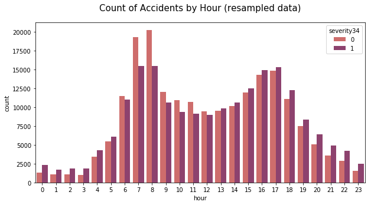

```python
plt.figure(figsize=(10,5))
df_bl.hour = df_bl.hour.astype(str)
labels = ["0","1", "2", "3", "4", "5", "6", "7", "8", "9", "10", "11", "12", "13", "14", "15", "16", "17", "18", "19", "20", "21", "22", "23"]
sns.countplot(x='hour', hue='severity34', data=df_bl ,palette="flare", order = labels)
plt.title('Count of Accidents by Hour (resampled data)', size=15, y=1.05)
plt.show()
```

### Location

In this part we will look at how geographic location changes your chances of a severe car crash.

```python
# resample again
df_bl = pd.concat([df[df['severity34']==1].sample(200000, replace = True),
                   df[df['severity34']==0].sample(200000)], axis=0)
```

This graph shows that it is much more dangerous to drive on the east coast than any other time zone; however, time zones are so large making it not very specific.

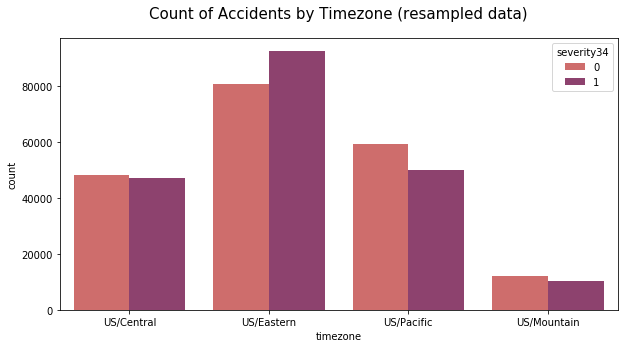

```python
plt.figure(figsize=(10,5))
df_bl.timezone = df_bl.timezone.astype(str)
sns.countplot(x='timezone', hue='severity34', data=df_bl ,palette="flare")
plt.title('Count of Accidents by Timezone (resampled data)', size=15, y=1.05)
plt.show()
```

California interestingly has more than double the car crashes than any other state's.

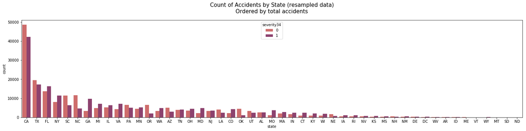

```python
plt.figure(figsize=(25,5))
sns.countplot(x='state', hue='severity34', data=df_bl ,palette="flare", order = df_bl['state'].value_counts().index)
plt.title('Count of Accidents by State (resampled data)\nOrdered by total accidents', size=15, y=1.05)
plt.show()
```

It is signifiganyly more dangerous to be driving on the right side of the road which is interesting. This may be due to turning right on red or something of that nature.

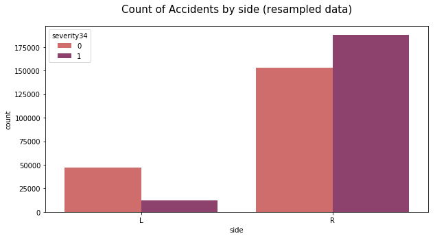

```python
plt.figure(figsize=(10,5))
df_bl.side = df_bl.side.astype(str)
sns.countplot(x='side', hue='severity34', data=df_bl ,palette="flare")
plt.title('Count of Accidents by side (resampled data)', size=15, y=1.05)
plt.show()
```

In this plot I plotted all the geographic coordinates and colored accidents of severity 1 and 2 green, 3 gold, and 4 red. It is interesting what this graph shows because it is very obious where the major cities in America are. Also it represents the timezone graph much better.

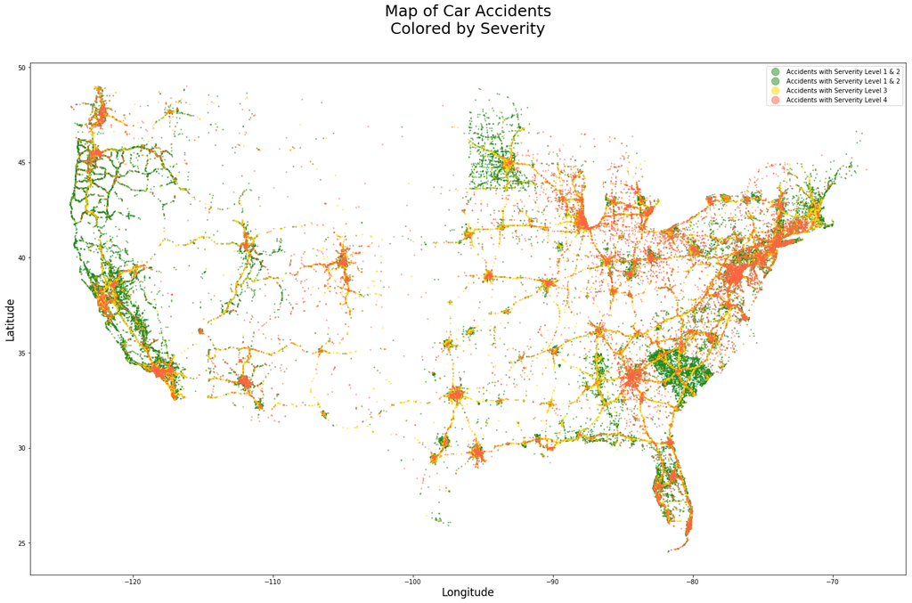

```python
%%capture --no-display
# resample again
df_bl = pd.concat([df[df['severity34']==1].sample(200000, replace = True),
                   df[df['severity34']==0].sample(200000)], axis=0)

df_1 = df_bl[df_bl['severity']==1]
df_2 = df_bl[df_bl['severity']==2]
df_3 = df_bl[df_bl['severity']==3]
df_4 = df_bl[df_bl['severity']==4]

plt.figure(figsize=(25,15))

plt.plot( 'long', 'lat', data=df_1, linestyle='', marker='o', markersize=1.5, color="forestgreen", alpha=0.5, label='Accidents with Serverity Level 1 & 2')
plt.plot( 'long', 'lat', data=df_2, linestyle='', marker='o', markersize=1.5, color="forestgreen", alpha=0.5, label='Accidents with Serverity Level 1 & 2')
plt.plot( 'long', 'lat', data=df_3, linestyle='', marker='o', markersize=1.5, color="gold", alpha=0.5, label='Accidents with Serverity Level 3')
plt.plot( 'long', 'lat', data=df_4, linestyle='', marker='o', markersize=1.5, color="tomato", alpha=0.5, label='Accidents with Serverity Level 4')
plt.legend(markerscale=8)
plt.xlabel('Longitude', size=17, labelpad=3)
plt.ylabel('Latitude', size=17, labelpad=3)
plt.title('Map of Car Accidents\nColored by Severity', size=25, y=1.05)
plt.show()
```

I wanted to create new features that represented the frequency of the different names that appear in the object type columns. This is necessary if i want to use them in my model.

```python
df['street_freq'] = df['street'].copy()
df['city_freq'] = df['city'].copy()
df['county_freq'] = df['county'].copy()
df['zipcode_freq'] = df['zipcode'].copy()
df['airport_code_freq'] = df['airport_code'].copy()
```

```python
freq = ['street_freq', 'city_freq', 'county_freq', 'zipcode_freq', 'airport_code_freq']
for i in freq:
  df[i] = df.groupby([i])[i].transform('count')
  df[i] = df[i]/df.shape[0]*df[i].unique().size
  df[i] = df[i].apply(lambda x: np.log(x+1))
df[freq].head()
```

|  | street_freq | city_freq | county_freq | zipcode_freq | airport_code_freq |
| --- | --- | --- | --- | --- | --- |
| 0 | 1.357442 | 1.847511 | 2.701087 | 0.090241 | 0.939052 |
| 1 | 0.022166 | 0.092007 | 1.479307 | 0.000379 | 1.154891 |
| 2 | 0.040218 | 0.270976 | 0.100074 | 0.004163 | 0.185145 |
| 3 | 1.797951 | 1.847511 | 2.701087 | 0.315209 | 1.046347 |
| 4 | 0.170264 | 1.847511 | 2.701087 | 0.195718 | 0.861937 |

### Weather Conditions

This is where I look at all the columns I made that relate to specific weather conditions.

```python
# resample again
df_bl = pd.concat([df[df['severity34']==1].sample(200000, replace = True),
                   df[df['severity34']==0].sample(200000)], axis=0)
```

```python
df_clear = df_bl[df_bl['clear']==1]
df_cloud = df_bl[df_bl['cloud']==1]
df_fog = df_bl[df_bl['fog']==1]

df_rain = df_bl[df_bl['rain']==1]
df_heavy_rain = df_bl[df_bl['heavy_rain']==1]

df_snow = df_bl[df_bl['snow']==1]
df_heavy_snow = df_bl[df_bl['heavy_snow']==1]
```

Clear and cloudy days have more severe car accidents. This could be because when there is good weather people may drive faster and more recklessly. On the other hand, fog has many more nonsevere accidents. I think that this is becasue people drive slower when visibility is low, and unlike rain and snow, fog doesnt change the road's physical condition.

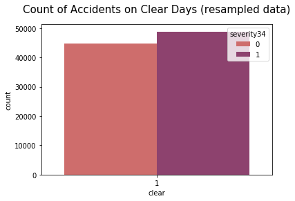

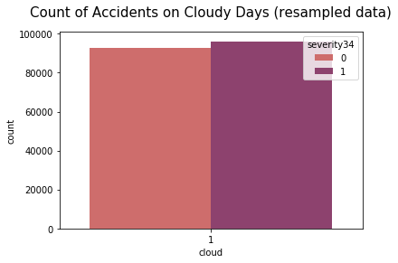

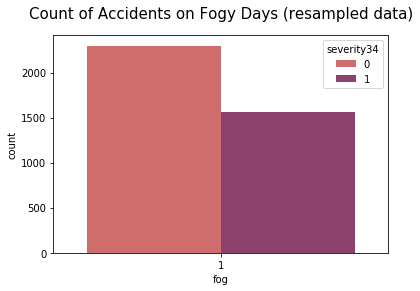

```python
sns.countplot(x= 'clear', hue = 'severity34', data = df_clear, palette="flare")
plt.title('Count of Accidents on Clear Days (resampled data)', size=15, y=1.05)
plt.show()

sns.countplot(x= 'cloud', hue = 'severity34', data = df_cloud, palette="flare")
plt.title('Count of Accidents on Cloudy Days (resampled data)', size=15, y=1.05)
plt.show()

sns.countplot(x= 'fog', hue = 'severity34', data = df_fog, palette="flare")
plt.title('Count of Accidents on Fogy Days (resampled data)', size=15, y=1.05)
plt.show()
```

These graphs reflect exactly what I would imagine because there are more severe accidents due to the road condition being worse, and there is a higher frequency of severe accidents in more severe weather conditions.

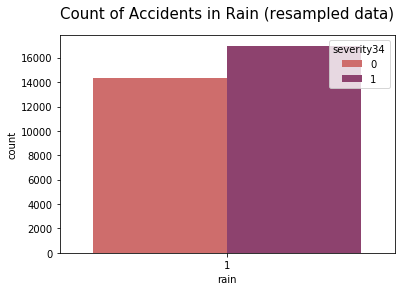

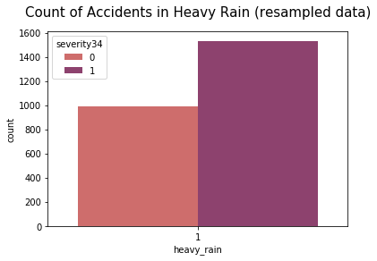

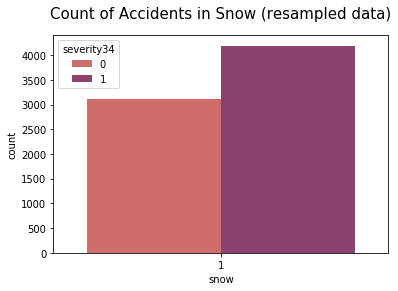

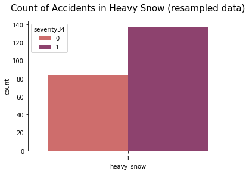

```python
sns.countplot(x= 'rain', hue = 'severity34', data = df_rain, palette="flare")
plt.title('Count of Accidents in Rain (resampled data)', size=15, y=1.05)
plt.show()

sns.countplot(x= 'heavy_rain', hue = 'severity34', data = df_heavy_rain, palette="flare")
plt.title('Count of Accidents in Heavy Rain (resampled data)', size=15, y=1.05)
plt.show()

sns.countplot(x= 'snow', hue = 'severity34', data = df_snow, palette="flare")
plt.title('Count of Accidents in Snow (resampled data)', size=15, y=1.05)
plt.show()

sns.countplot(x= 'heavy_snow', hue = 'severity34', data = df_heavy_snow, palette="flare")
plt.title('Count of Accidents in Heavy Snow (resampled data)', size=15, y=1.05)
plt.show()
```

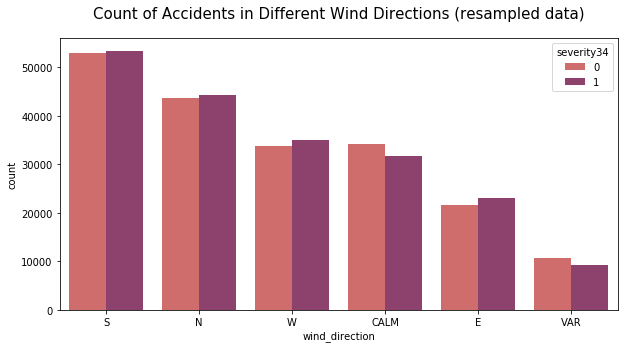

```python
plt.figure(figsize = (10,5))
sns.countplot(x= 'wind_direction', hue = 'severity34', data = df_bl, palette="flare")
plt.title('Count of Accidents in Different Wind Directions (resampled data)', size=15, y=1.05)
plt.show()
```

### Infrastructure

Here I am going to look at how different road infrastructures affects safety.

```python
# resample again
df_bl = pd.concat([df[df['severity34']==1].sample(200000, replace = True),
                   df[df['severity34']==0].sample(200000)], axis=0)
```

Simmilar to Weather Conditions, I only want to look at the Infrastructure data when the column value is true.

```python
df_amenity = df_bl[df_bl['amenity']== True]
df_station = df_bl[df_bl['station']== True]

df_traffic_calming = df_bl[df_bl['traffic_calming']== True]
df_bump = df_bl[df_bl['bump']== True]
df_traffic_signal = df_bl[df_bl['traffic_signal']== True]
df_stop = df_bl[df_bl['stop']== True]
df_give_way = df_bl[df_bl['give_way']== True]

df_junction = df_bl[df_bl['junction']== True]
df_roundabout = df_bl[df_bl['roundabout']== True]
df_no_exit = df_bl[df_bl['no_exit']== True]

df_crossing = df_bl[df_bl['crossing']== True]
df_railway = df_bl[df_bl['railway']== True]
```

These graphs show places of low speed. When you get off the highway for a rest stop or when you are going to a train station it is not a high speed situation and many times you are in a parking lot. The large count of low severity crashes makes sense.

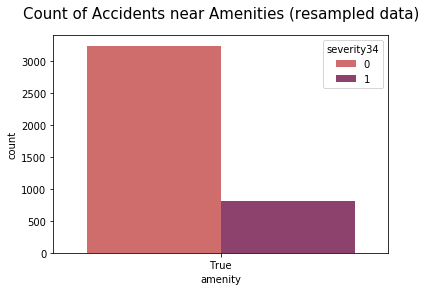

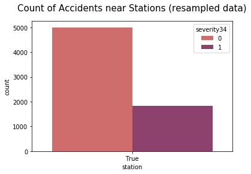

```python
sns.countplot(x= 'amenity', hue = 'severity34', data = df_amenity, palette="flare")
plt.title('Count of Accidents near Amenities (resampled data)', size=15, y=1.05)
plt.show()

sns.countplot(x= 'station', hue = 'severity34', data = df_station, palette="flare")
plt.title('Count of Accidents near Stations (resampled data)', size=15, y=1.05)
plt.show()
```

SImilar to the last set of graphs, all of these features are put in place on to slow people down on the road. Having severe crashes at low speed is hard.

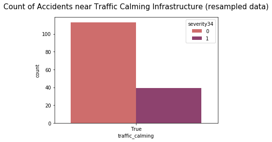

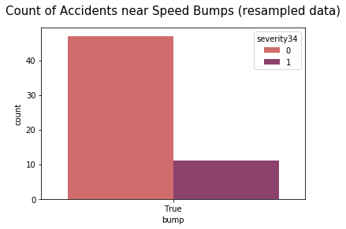

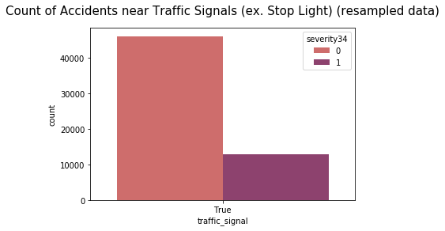

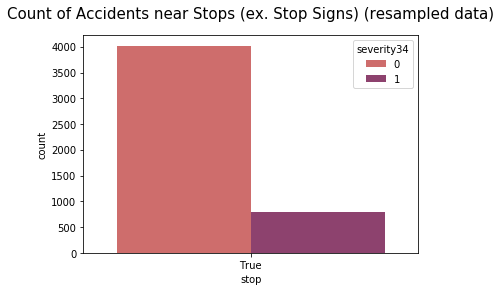

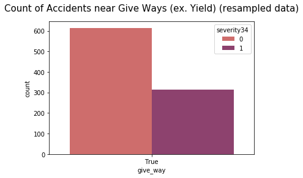

```python
sns.countplot(x= 'traffic_calming', hue = 'severity34', data = df_traffic_calming, palette="flare")
plt.title('Count of Accidents near Traffic Calming Infrastructure (resampled data)', size=15, y=1.05)
plt.show()

sns.countplot(x= 'bump', hue = 'severity34', data = df_bump, palette="flare")
plt.title('Count of Accidents near Speed Bumps (resampled data)', size=15, y=1.05)
plt.show()

sns.countplot(x= 'traffic_signal', hue = 'severity34', data = df_traffic_signal, palette="flare")
plt.title('Count of Accidents near Traffic Signals (ex. Stop Light) (resampled data)', size=15, y=1.05)
plt.show()

sns.countplot(x= 'stop', hue = 'severity34', data = df_stop, palette="flare")
plt.title('Count of Accidents near Stops (ex. Stop Signs) (resampled data)', size=15, y=1.05)
plt.show()

sns.countplot(x= 'give_way', hue = 'severity34', data = df_give_way, palette="flare")
plt.title('Count of Accidents near Give Ways (ex. Yield) (resampled data)', size=15, y=1.05)
plt.show()
```

I am supprised about the amount of severe accidents around road juntions because both round abouts and dead ends are types of road junctions but they both result in low amounts of severe accidents.

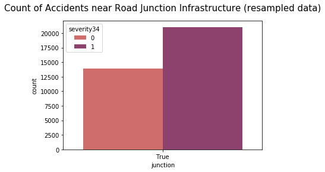

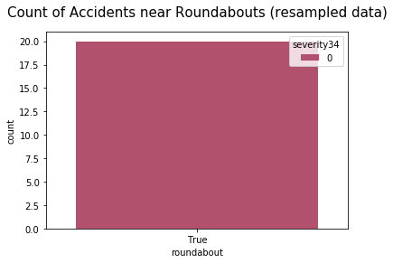

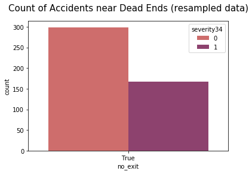

```python
sns.countplot(x= 'junction', hue = 'severity34', data = df_junction, palette="flare")
plt.title('Count of Accidents near Road Junction Infrastructure (resampled data)', size=15, y=1.05)
plt.show()

sns.countplot(x= 'roundabout', hue = 'severity34', data = df_roundabout, palette="flare")
plt.title('Count of Accidents near Roundabouts (resampled data)', size=15, y=1.05)
plt.show()

sns.countplot(x= 'no_exit', hue = 'severity34', data = df_no_exit, palette="flare")
plt.title('Count of Accidents near Dead Ends (resampled data)', size=15, y=1.05)
plt.show()
```

### Correlation

Now I want to see how different features correlate to `severity34` so i made dataframes for each category of features.

```python
df_bl['severity34'] = df_bl['severity34'].astype(int)
```

I had to drop the NaN from the weather features.

```python
df = df.dropna(subset = ['wind_direction','clear', 'cloud', 'rain', 'heavy_rain', 'snow', 'heavy_snow', 'fog'])
```

```python
# resample again
df_bl = pd.concat([df[df['severity34']==1].sample(200000, replace = True),
                   df[df['severity34']==0].sample(200000)], axis=0)
```

```python
infrastructure_df_bl = df_bl[['severity34', 'amenity', 'station', 'traffic_calming', 'bump', 'traffic_signal', 'stop', 'give_way', 'junction', 'roundabout', 'no_exit', 'crossing', 'railway']]
street_df_bl  = df_bl[['severity34','rd','st','dr','ave','blvd','ln','highway','pkwy','hwy','way','ct','pl','road','us-','creek','cir','hill','route','i-','trl','valley','ridge','pike','fwy','river']]
weatherCat_df_bl = df_bl[['severity34', 'clear', 'cloud', 'rain', 'heavy_rain', 'snow', 'heavy_snow', 'fog']].astype(int)
weatherCont_df_bl = df_bl[['severity34','temperature(f)','humidity(%)','pressure(in)','visibility(mi)','wind_speed(mph)']]
time_df_bl = df_bl[['severity34', 'year', 'month', 'weekday', 'day_night', 'hour']]
```

For the street category I want to drop all columns that has less than a |.1| correlation to severity34

```python
df_bl['severity34'] = df_bl['severity34'].astype(int)
st_corr  = df_bl[['severity34','rd','st','dr','ave','blvd','ln','highway','pkwy','hwy','way','ct','pl','road','us-','creek','cir','hill','route','i-','trl','valley','ridge','pike','fwy','river']].corr()

little_corr_st = st_corr.index[st_corr['severity34'].abs()<0.1].to_list()
df = df.drop(little_corr_st, axis=1)
street_df_bl = street_df_bl.drop(little_corr_st, axis=1)
```

All these tables are colored blue with darker colors representing stronger positive correlation.

```python
infrastructure_df_bl.corr().style.background_gradient(cmap='Blues').format("{:.2f}")
```

|  | severity34 | amenity | station | traffic_calming | bump | traffic_signal | stop | give_way | junction | roundabout | no_exit | crossing | railway |
| --- | --- | --- | --- | --- | --- | --- | --- | --- | --- | --- | --- | --- | --- |
| severity34 | 1.00 | -0.06 | -0.06 | -0.01 | -0.01 | -0.23 | -0.07 | -0.02 | 0.07 | -0.01 | -0.01 | -0.17 | -0.03 |
| amenity | -0.06 | 1.00 | 0.18 | 0.01 | 0.00 | 0.10 | 0.04 | 0.00 | -0.03 | -0.00 | 0.02 | 0.12 | 0.05 |
| station | -0.06 | 0.18 | 1.00 | 0.01 | 0.00 | 0.12 | 0.03 | 0.00 | -0.03 | 0.00 | 0.01 | 0.12 | 0.18 |
| traffic_calming | -0.01 | 0.01 | 0.01 | 1.00 | 0.64 | 0.01 | 0.01 | -0.00 | -0.00 | -0.00 | 0.02 | 0.02 | -0.00 |
| bump | -0.01 | 0.00 | 0.00 | 0.64 | 1.00 | -0.00 | 0.01 | -0.00 | 0.00 | -0.00 | 0.03 | 0.01 | -0.00 |
| traffic_signal | -0.23 | 0.10 | 0.12 | 0.01 | -0.00 | 1.00 | -0.03 | 0.05 | -0.12 | -0.00 | 0.02 | 0.45 | 0.05 |
| stop | -0.07 | 0.04 | 0.03 | 0.01 | 0.01 | -0.03 | 1.00 | 0.04 | -0.03 | 0.01 | 0.00 | 0.07 | 0.01 |
| give_way | -0.02 | 0.00 | 0.00 | -0.00 | -0.00 | 0.05 | 0.04 | 1.00 | -0.01 | -0.00 | 0.02 | 0.07 | -0.00 |
| junction | 0.07 | -0.03 | -0.03 | -0.00 | 0.00 | -0.12 | -0.03 | -0.01 | 1.00 | 0.02 | -0.00 | -0.07 | -0.01 |
| roundabout | -0.01 | -0.00 | 0.00 | -0.00 | -0.00 | -0.00 | 0.01 | -0.00 | 0.02 | 1.00 | -0.00 | -0.00 | -0.00 |
| no_exit | -0.01 | 0.02 | 0.01 | 0.02 | 0.03 | 0.02 | 0.00 | 0.02 | -0.00 | -0.00 | 1.00 | 0.05 | 0.00 |
| crossing | -0.17 | 0.12 | 0.12 | 0.02 | 0.01 | 0.45 | 0.07 | 0.07 | -0.07 | -0.00 | 0.05 | 1.00 | 0.21 |
| railway | -0.03 | 0.05 | 0.18 | -0.00 | -0.00 | 0.05 | 0.01 | -0.00 | -0.01 | -0.00 | 0.00 | 0.21 | 1.00 |

```python
street_df_bl.corr().style.background_gradient(cmap='Blues').format("{:.2f}")
```

|  | severity34 | rd | st | dr | i- |
| --- | --- | --- | --- | --- | --- |
| severity34 | 1.00 | -0.15 | -0.11 | -0.11 | 0.36 |
| rd | -0.15 | 1.00 | -0.10 | -0.08 | -0.26 |
| st | -0.11 | -0.10 | 1.00 | -0.06 | -0.21 |
| dr | -0.11 | -0.08 | -0.06 | 1.00 | -0.12 |
| i- | 0.36 | -0.26 | -0.21 | -0.12 | 1.00 |

```python
weatherCat_df_bl.corr().style.background_gradient(cmap='Blues').format("{:.2f}")
```

|  | severity34 | clear | cloud | rain | heavy_rain | snow | heavy_snow | fog |
| --- | --- | --- | --- | --- | --- | --- | --- | --- |
| severity34 | 1.00 | 0.03 | 0.02 | 0.03 | 0.02 | 0.02 | 0.01 | -0.02 |
| clear | 0.03 | 1.00 | -0.54 | -0.16 | -0.05 | -0.08 | -0.01 | -0.06 |
| cloud | 0.02 | -0.54 | 1.00 | -0.28 | -0.08 | -0.13 | -0.02 | -0.10 |
| rain | 0.03 | -0.16 | -0.28 | 1.00 | 0.28 | -0.04 | -0.01 | -0.03 |
| heavy_rain | 0.02 | -0.05 | -0.08 | 0.28 | 1.00 | -0.01 | -0.00 | -0.01 |
| snow | 0.02 | -0.08 | -0.13 | -0.04 | -0.01 | 1.00 | 0.17 | -0.01 |
| heavy_snow | 0.01 | -0.01 | -0.02 | -0.01 | -0.00 | 0.17 | 1.00 | -0.00 |
| fog | -0.02 | -0.06 | -0.10 | -0.03 | -0.01 | -0.01 | -0.00 | 1.00 |

```python
weatherCont_df_bl.corr().style.background_gradient(cmap='Blues').format("{:.2f}")
```

|  | severity34 | temperature(f) | humidity(%) | pressure(in) | visibility(mi) | wind_speed(mph) |
| --- | --- | --- | --- | --- | --- | --- |
| severity34 | 1.00 | -0.02 | 0.03 | 0.04 | -0.01 | 0.04 |
| temperature(f) | -0.02 | 1.00 | -0.33 | -0.03 | 0.18 | -0.02 |
| humidity(%) | 0.03 | -0.33 | 1.00 | 0.11 | -0.39 | -0.14 |
| pressure(in) | 0.04 | -0.03 | 0.11 | 1.00 | -0.02 | -0.00 |
| visibility(mi) | -0.01 | 0.18 | -0.39 | -0.02 | 1.00 | 0.01 |
| wind_speed(mph) | 0.04 | -0.02 | -0.14 | -0.00 | 0.01 | 1.00 |

```python
time_df_bl.corr().style.background_gradient(cmap='Blues').format("{:.2f}")
```

|  | severity34 | year | month | weekday | hour |
| --- | --- | --- | --- | --- | --- |
| severity34 | 1.00 | -0.09 | -0.00 | 0.08 | 0.03 |
| year | -0.09 | 1.00 | -0.34 | 0.04 | -0.02 |
| month | -0.00 | -0.34 | 1.00 | -0.00 | 0.01 |
| weekday | 0.08 | 0.04 | -0.00 | 1.00 | 0.04 |
| hour | 0.03 | -0.02 | 0.01 | 0.04 | 1.00 |

Now I want to drop all features with poor correlation.

```python
df = df.drop(['precipitation(in)','day','minute', 'street', 'city', 'county', 'zipcode', 'airport_code'], axis=1)
```

### One-hot Encoding

One-hot Encoding is the process of turning every category in a column into its own column with a 1 or 0 representing if the column condition is True or False.

```python
df = df.replace([True, False], [1,0])
df = df.replace(['Day', 'Night'], [1,0])

cat = ['side','state','timezone','wind_direction', 'weekday', 'month', 'hour', 'day_night']
df[cat] = df[cat].astype('category')
df = pd.get_dummies(df, columns=cat, drop_first=True)
df = df.dropna()
```

```python
df = df.dropna()
```

## Model

This is the step where I build my 2 classification models.

Function to plot confusion matrix

```python
def plot_confusion_matrix(cm, classes,
                          normalize=False,
                          title='Confusion matrix',
                          cmap=plt.cm.Blues):
    """
    This function prints and plots the confusion matrix.
    Normalization can be applied by setting `normalize=True`.
    """
    if normalize:
        cm = cm.astype('float') / cm.sum(axis=1)[:, np.newaxis]
        print("Normalized confusion matrix")
    else:
        print('Confusion matrix, without normalization')

    print(cm)

    plt.imshow(cm, interpolation='nearest', cmap=cmap)
    plt.title(title)
    plt.colorbar()
    tick_marks = np.arange(len(classes))
    plt.xticks(tick_marks, classes, rotation=45)
    plt.yticks(tick_marks, classes)

    fmt = '.2f' if normalize else 'd'
    thresh = cm.max() / 2.
    for i, j in itertools.product(range(cm.shape[0]), range(cm.shape[1])):
        plt.text(j, i, format(cm[i, j], fmt),
                 horizontalalignment="center",
                 color="white" if cm[i, j] > thresh else "black")

    plt.tight_layout()
    plt.ylabel('True label')
    plt.xlabel('Predicted label')
```

### Train Test Split

Here I need to split my data into a training set and a testing set with **X** representing the features that I want to use to predict **y** which is the target feature `severity34`. I want the training set to have 80% of the data so that I can get the best results classifying the test set.

```python
# resample again
df_bl = pd.concat([df[df['severity34']==1].sample(200000, replace = True),
                   df[df['severity34']==0].sample(200000)], axis=0)
```

```python
X = np.asarray(df_bl.drop(['severity','severity34'], axis = 1))
y = np.asarray(df_bl['severity34'])
```

```python
X = StandardScaler().fit(X).transform(X)
```

```python
X_train, X_test, y_train, y_test = train_test_split(X, y, test_size=0.20, random_state=6)

print ('Train set:\n', 'X_train: ', X_train.shape, '\n',  'y_train: ', y_train.shape)
print()
print ('Test set:\n', 'X_test: ', X_test.shape, '\n',  'y_test: ', y_test.shape)
```

```
Train set:
 X_train:  (320000, 135)
 y_train:  (320000,)

Test set:
 X_test:  (80000, 135)
 y_test:  (80000,)
```

### Logistic Regression

Logistic Regression is a bianary classification algorithm that uses the sigmoid fuction to distinguish categories. It calculates a probibility for the value of y and it checks that probibility to determine its category.

$$ ℎ_\theta(𝑥) = \sigma({\theta^TX}) = \frac {e^{(\theta_0 + \theta_1 x_1 + \theta_2 x_2 +...)}}{1 + e^{(\theta_0 + \theta_1 x_1 + \theta_2 x_2 +\cdots)}} $$$$\text{Or:}$$$$ \text{Probability Of a Class 1} = P(Y=1|X) = \sigma({\theta^TX}) = \frac{e^{\theta^TX}}{1+e^{\theta^TX}} $$

First we need to build our model to the best availible parameters. After we build the model, we fit it with the training feature set and result set inorder to teach the model.

```python
LR = LogisticRegression(C=1,
                         solver='saga',
                         random_state=42,
                         max_iter = 10000,
                         penalty = 'l1').fit(X_train,y_train)
LR
```

```
LogisticRegression(C=1, max_iter=10000, penalty='l1', random_state=42,
                   solver='saga')
```

After fitting the model we should use it to predict the y test values so we imput the X test set and get an array of predicted values

```python
yhat = LR.predict(X_test)
print("Predicted test set: ", yhat[0:10])
print("Actual test set:    ", y_test[0:10])
```

```
Predicted test set:  [0 0 1 0 0 0 0 1 1 0]
Actual test set:     [0 0 1 0 0 1 0 0 0 1]
```

```python
yhat_prob = LR.predict_proba(X_test)

print('Probability of X Being a 1 or 0:')
print('Key:')
print('[0 1]')
print()
print(yhat_prob[0:10])
```

```
Probability of X Being a 1 or 0:
Key:
[0 1]

[[0.71207834 0.28792166]
 [0.52330609 0.47669391]
 [0.38661739 0.61338261]
 [0.73424099 0.26575901]
 [0.83176861 0.16823139]
 [0.54583415 0.45416585]
 [0.67752589 0.32247411]
 [0.37075714 0.62924286]
 [0.33927047 0.66072953]
 [0.80626035 0.19373965]]
```

```python
atrain = LR.score(X_train, y_train)
print("Train Accuracy: %.1f%%"% (atrain*100))
atest = LR.score(X_test,y_test)
print("Test Accuracy: %.1f%%"% (atest*100))
```

```
Train Accuracy: 73.9%
Test Accuracy: 73.9%
```

#### Jaccard index

Lets try jaccard index for accuracy evaluation. we can define jaccard as the size of the intersection divided by the size of the union of two label sets. If the entire set of predicted labels for a sample strictly match with the true set of labels, then the subset accuracy is 1.0; otherwise it is 0.0.

```python
LR_js = jaccard_score(y_test, yhat)
print("Jaccard Score: ", LR_js)
```

```
Jaccard Score:  0.588180815007488
```

#### Log loss

Now, lets try log loss for evaluation. In logistic regression, the output can be the probability of 3/4 severity accident (or equals to 1). This probability is a value between 0 and 1. Log loss (Logarithmic loss) measures the performance of a classifier where the predicted output is a probability value between 0 and 1.

```python
LR_ll = log_loss(y_test, yhat_prob)
print("Log Loss Score: ", LR_ll)
```

```
Log Loss Score:  0.5381339892611274
```

#### Confusion Matrix

Another way of looking at accuracy of classifier is to look at **confusion matrix**.

```
Confusion matrix, without normalization
[[29849 10128]
 [10771 29252]]
```

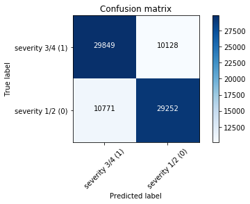

```python
# Compute confusion matrix
cnf_matrix = confusion_matrix(y_test, yhat, labels=[1,0])
np.set_printoptions(precision=2)

# Plot non-normalized confusion matrix
plt.figure()
plot_confusion_matrix(cnf_matrix, classes=['severity 3/4 (1)','severity 1/2 (0)'],normalize= False,  title='Confusion matrix')
```

### Decision Tree

A decision tree is also a good method to use when trying to classify data. Like with the regression model, we need to build and then fit the decision tree classifier model.

```python
severityTree = DecisionTreeClassifier(criterion = 'entropy', class_weight = 'balanced', min_samples_split = 40, random_state = 42)
severityTree
```

```
DecisionTreeClassifier(class_weight='balanced', criterion='entropy',
                       min_samples_split=40, random_state=42)
```

```python
severityTree.fit(X_train,y_train)
```

```
DecisionTreeClassifier(class_weight='balanced', criterion='entropy',
                       min_samples_split=40, random_state=42)
```

After fitting the model, we need to input the X test values to find the predicted Y values

```python
predTree = severityTree.predict(X_test)
```

```python
print("Predicted test set: ", predTree[0:10])
print("Actual test set:    ", y_test[0:10])
```

```
Predicted test set:  [0 0 1 0 0 1 0 0 1 0]
Actual test set:     [0 0 1 0 0 1 0 0 0 1]
```

This decision tree is also fairly inaccurate with a score of 82%.

```python
print("DecisionTrees's Accuracy: ", accuracy_score(y_test, predTree))
```

```
DecisionTrees's Accuracy:  0.81945
```

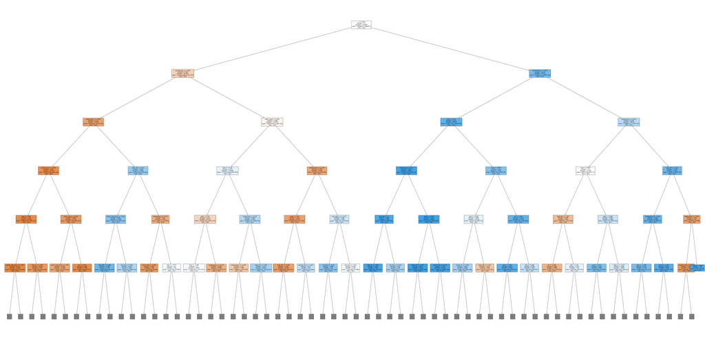

```python
fig, ax = plt.subplots(figsize=(100, 50))
plot_tree(severityTree, max_depth=5, fontsize=10,
               feature_names=df.drop(['severity', 'severity34'],axis = 1).columns.to_list(),
               class_names = True, filled=True)
plt.show()
```

## Results & Discussion

Unfortunatly, my classification models arent accurate; however given more time I would be able to drasticly imporove them. I think I could select features for the model better relating to their correlation but I did not have the time.

Our exploratory analysis showed really interesting trends with the data. I was not expecting time so correlate with severity. There were many obvious trends on all the graphs relating to time and it is something worth exploring more. On the other hand, I was supprised by how little of a true corelation there was between the weather conditions and severity, but again, I need to spend more time exploring.

## Conclusion

My objective in this project was to be able to predict severity off of the features in this data and I wasnt able to do that with the level of confidence I would like. However, this is still a helpful project for all the resons I wanted. This will give first responders an idea of the urgency of a call and it can help show drivers when and where it is safe to drive.